# Module 1, Lecture 10: I/O, Libraries/Packages, Bioconductor

author: M Hallett date: January 2016 autosize:true font-family: ‘Helvetica’ #output: beamer-presentation

Reading and writing to/from R; R Libraries & Packages; The Bioconductor Project

## COMP-364 Tools for the Life Sciences

# Previously (Lecture 5) … Importing a csv file into R

- A typical situation is that you have a spreadsheet, or simply a file that contains information about a set of objects.
- `csv` is a common code for storing information in files (comma separated values)
- For example, the set of genes that are used in Oncotype Dx. (up in bad outcome)

  ```
   GeneName,Direction CCNB1,up
   MKI67,up
   MYBL2,up
   AURKA,up
   BIRC5,up
   ERBB2,up
   GRB7,up
   CTSL2,up
   MMP11,up
   CD68,up
   BCL2,down
   SCUBE2,down
   ESR1,down
   PGR,down
   BAG1,down
   GSTM1,down
  ```

# Revisited: Importing a csv file into R (2)

- This is your typical csv file that can be generated from Excel, Numbers, etc.
- we assume that this file is named `oncotypedx.csv`
- we assume it’s located in our working directory (eg ~/repos/comp364)

```r
setwd("~/repos/comp364/lectures/MiscFiles")
# first do: help read.csv
oncotype.dx.genes <- read.csv( file ="oncotypedx.csv", header = TRUE, sep = ",")
oncotype.dx.genes[1:5,]
```

```
  GeneName Direction
1    CCNB1        up
2    MKI67        up
3    MYBL2        up
4    AURKA        up
5    BIRC5        up
```

```r
class(oncotype.dx.genes)
```

```
[1] "data.frame"
```

# Revisited: Importing a csv file into R (2)

```r
attach(oncotype.dx.genes)
class(GeneName); class(Direction)
```

```
[1] "factor"
```

```
[1] "factor"
```

```r
Direction
```

```
 [1] up   up   up   up   up   up   up   up   up   up   down down down down
[15] down down
Levels: down up
```

```r
detach(oncotype.dx.genes)
```

# The read.table() function

- csv (comma seperated values) is a common format for data many alternatives exist.
- In general, the `read.table()` function with its many parameters handles almost everything.
- Here is a modified version of oncotypedx.csv where “,” seperators are replaced by tabs (${\tt \t}$) and there is no header.

```
 Unix prompt$ cat oncotypedx.file
 CCNB1 up
 MKI67 up
 MYBL2 up
 AURKA up
 BIRC5 up
 ERBB2 up
 GRB7 up
 CTSL2 up
 MMP11 up
 CD68 up
 BCL2 down
 SCUBE2 down
 ESR1 down
 PGR down
 BAG1 down
 GSTM1 down
```

# The read.table() function

```r
? read.table

setwd("~/repos/comp364/lectures/MiscFiles")

(oncotype.dx.genes2 <- read.table(
                        file ="oncotypedx.file",
                        header = FALSE,
                        sep = "\t"))
```

```
       V1   V2
1   CCNB1   up
2   MKI67   up
3   MYBL2   up
4   AURKA   up
5   BIRC5   up
6   ERBB2   up
7    GRB7   up
8   CTSL2   up
9   MMP11   up
10   CD68   up
11   BCL2 down
12 SCUBE2 down
13   ESR1 down
14    PGR down
15   BAG1 down
16  GSTM1 down
```

# Saving data to file and reading it back in

```r
dani <- file("daniel.speaks", "w")
# open an output file connection

cat("But soft what light", "through yonger window breaks",
      "it is the east and Katy is my sun",
      file = dani, sep = "\n")

cat("Two of the sweetest stars in all the heavens ...\n",
    file = dani)

close(dani)
```

- This text is now in a file called “daniel.speaks” in the working directory (${\tt ~/repos/comp364/lecures/MiscFiles}$)
- In Unix in the current working directory, type `ls` and then `cat daniel.speaks`.

# Saving data to file and reading it back in

```r
# now read it back in.
readLines("daniel.speaks")
```

```
[1] "But soft what light"
[2] "through yonger window breaks"
[3] "it is the east and Katy is my sun"
[4] "Two of the sweetest stars in all the heavens ..."
```

```r
# very basic low level function that reads all the text from a connection ("daniel.speaks" in this case)

unlink("daniel.speaks")
# this deletes the connection. In this case, a file called "daniel.speaks"
```

# The write.table() function

- An easier way to write to a table

```r
write.table( oncotype.dx.genes,
            file = "onco.semicolon",
            sep = ";",
            col.names = FALSE)
```

# The write.table() function

```
 Unix prompt$ cat onco.semicolon
 * (If we added a  row.names = FALSE  parameter, the numbers would disappear.)
 “1”;“CCNB1”;“up”
 “2”;“MKI67”;“up”
 “3”;“MYBL2”;“up”
 “4”;“AURKA”;“up”
 “5”;“BIRC5”;“up”
 “6”;“ERBB2”;“up”
 “7”;“GRB7”;“up”
 “8”;“CTSL2”;“up”
 “9”;“MMP11”;“up”
 “10”;“CD68”;“up”
 “11”;“BCL2”;“down”
 “12”;“SCUBE2”;“down”
 “13”;“ESR1”;“down”
 “14”;“PGR”;“down”
 “15”;“BAG1”;“down”
 “16”;“GSTM1”;“down”
```

# The save() and load() functions

- These are nice functions that allow you to save to file an R object, and read that R object back in.

```r
(m <- matrix(data = seq(from=1, to=20, by=2 ), nrow = 5, ncol=2))
```

```
     [,1] [,2]
[1,]    1   11
[2,]    3   13
[3,]    5   15
[4,]    7   17
[5,]    9   19
```

```r
(n <- data.frame(first.love="katy", second.love="taylor"))
```

```
  first.love second.love
1       katy      taylor
```

```r
save(m, n, file = "such.a.boring.example")
```

# The save() and load() functions

```r
m <- NA; n <- NA
m; n
```

```
[1] NA
```

```
[1] NA
```

```r
(my.long.lost.thoughts <- load("such.a.boring.example"))
```

```
[1] "m" "n"
```

```r
n
```

```
  first.love second.love
1       katy      taylor
```

# save.image()

- Related to `save()` is the `save.image()` function.
- This function saves your entire R workshop.
- In RStudio, if you have created a project, `save.image()` is automatically called and stored in a file called `.RData`

  ```
   Unix prompt$ ls -a

   …
   .RData
   …
  ```

# The save() and load() functions

- (In Unix, files that start with a period (.) are hidden with the `ls` command by default. Use `ls -a`)
- So when you kill your browser or the R session in RStudio, it makes sure to update the .RData file so that you don’t lose your work.

# The Libraries of R

- All functions and objects in R belong to a `package`.
- There are currently **6131** packages for R available at [CRAN (Comprehnsive R Archive Network) http://cran.r-project.org/](http://cran.r-project.org/)
- Packages allow related functions/data to be grouped together. You can load only these functions/data when you need them.
- (Consider an R world without packages, or something like packages. How would you find things? If you just loaded *everything*, what would be some problems?)
- To check what packages are currently loaded in your session of R:

```r
search()
```

```
 [1] ".GlobalEnv"        "package:knitr"     "package:stats"
 [4] "package:graphics"  "package:grDevices" "package:utils"
 [7] "package:datasets"  "package:methods"   "Autoloads"
[10] "package:base"
```

# The Libraries of R

- With the exception of `knitr`, these packages are in every R session by default since they are so important and central.
- They are called the *standard* or *base* packages.
- (`knitr` is a package that RStudio has loaded for me because I am using `knitr` to make this presentation!)

# The Libraries of R

- To check what packages are available at our installation of R (the picture below is for me on my private server):

```r
library()
```

[figure not shown]

# The Libraries of R

- To check what packages are available at our installation of R (on the pepi.bci.mcgill.ca server):
- And five more pages like this. It’s because I use RStudio to develop all of my research projects. Overtime, we use hundreds of diferent packages.
- Because VennDiagram is a package in my library, I can load it easily:

```r
?? Venn
library(VennDiagram)
? VennDiagram
```

- The easiest thing to do is look up “R Venn Diagram” in Google search for the functions that are available.

# The Libraries of R (5D Venn is so Zen)

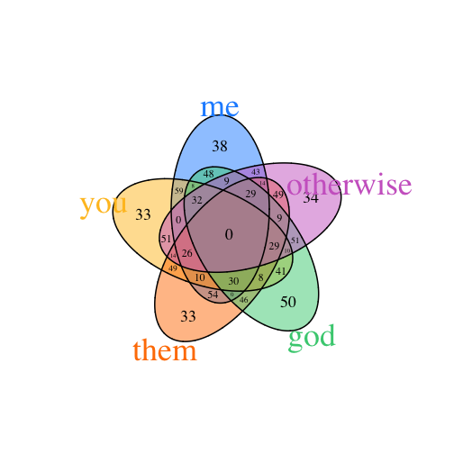

```r
# sample four-set Venn Diagram
set.seed(seed=5)
lst <- list()
lst[[1]] <- sample(1:1000, 400, replace = FALSE)
lst[[2]] <- sample(1:1000, 400, replace = FALSE)
lst[[3]] <- sample(1:1000, 400, replace = FALSE)
lst[[4]] <- sample(1:1000, 400, replace = FALSE)
lst[[5]] <- sample(1:1000, 400, replace = FALSE)
names(lst) <- c("me","you","them","god","otherwise")


venn.plot <- draw.quintuple.venn(

  # a lot of parameters!!!

  area1 = length(lst[[1]]), area2 = length(lst[[2]]), area3 = length(lst[[3]]), area4 = length(lst[[4]]),
  area5 = length(lst[[5]]),
  n12 = length(intersect(lst[[1]], lst[[2]])),  n13 = length(intersect(lst[[1]], lst[[3]])),
  n14 = length(intersect(lst[[1]], lst[[4]])),  n15 = length(intersect(lst[[1]], lst[[5]])),
  n23 = length(intersect(lst[[2]], lst[[3]])),  n24 = length(intersect(lst[[2]], lst[[4]])),
  n25 = length(intersect(lst[[2]], lst[[5]])),  n34 = length(intersect(lst[[3]], lst[[4]])),
  n35 = length(intersect(lst[[3]], lst[[5]])),  n45 = length(intersect(lst[[4]], lst[[5]])),
  n123 = length(intersect(lst[[1]], intersect(lst[[2]], lst[[3]]))),
  n124 = length(intersect(lst[[1]], intersect(lst[[2]], lst[[4]]))),
  n125 = length(intersect(lst[[1]], intersect(lst[[2]], lst[[5]]))),
  n134 = length(intersect(lst[[1]], intersect(lst[[3]], lst[[4]]))),
  n135 = length(intersect(lst[[1]], intersect(lst[[3]], lst[[5]]))),
  n145 = length(intersect(lst[[1]], intersect(lst[[4]], lst[[5]]))),
  n234 = length(intersect(lst[[2]], intersect(lst[[3]], lst[[4]]))),
  n235 = length(intersect(lst[[2]], intersect(lst[[3]], lst[[5]]))),
  n245 = length(intersect(lst[[2]], intersect(lst[[4]], lst[[5]]))),
  n345 = length(intersect(lst[[3]], intersect(lst[[4]], lst[[5]]))),
  n1234 = length(intersect( lst[[1]], intersect(lst[[2]], intersect(lst[[3]], lst[[4]])))),
  n1235 = length(intersect( lst[[1]], intersect(lst[[2]], intersect(lst[[3]], lst[[5]])))),
  n1245 = length(intersect( lst[[1]], intersect(lst[[2]], intersect(lst[[4]], lst[[5]])))),
  n1345 = length(intersect( lst[[1]], intersect(lst[[3]], intersect(lst[[4]], lst[[5]])))),
  n2345 = length(intersect( lst[[2]], intersect(lst[[3]], intersect(lst[[4]], lst[[5]])))),
  n12345 = length(intersect(lst[[1]], length(intersect( lst[[2]], intersect(lst[[3]], intersect(lst[[4]], lst[[5]])))))),
  category = names(lst),
  fill = c("dodgerblue", "goldenrod1", "darkorange1", "seagreen3", "orchid3"),
  cat.col = c("dodgerblue", "goldenrod1", "darkorange1", "seagreen3", "orchid3"),
  cat.cex = 3.0,
  margin = 0.5,
  cex = c(1.5, 1.5, 1.5, 1.5, 1.5, 1, 0.8, 1, 0.8, 1, 0.8, 1, 0.8, 1, 0.8,
          1, 0.55, 1, 0.55, 1, 0.55, 1, 0.55, 1, 0.55, 1, 1, 1, 1, 1, 1.5),
  ind = TRUE
);
```

The Libraries of R (5D Venn is so Zen) ========================================================

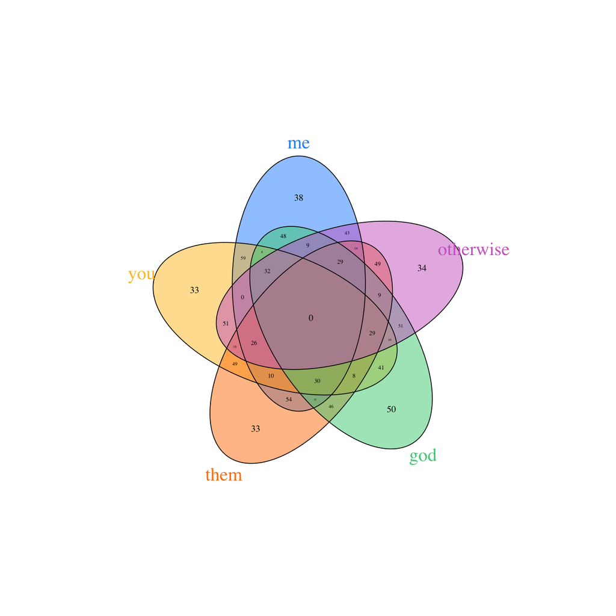

```r
png(file = "MyFigs/Quintuple_Venn_diagram.png", width=1200, height=1200);
grid.draw(venn.plot);
dev.off();
```

# The benefits of packages: scoping, public/private functions, etc.

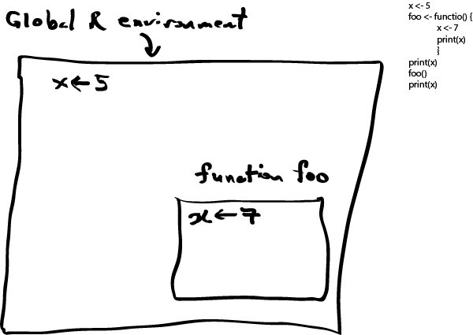

# Grabbing new packages from CRAN, Bioconductor, or elsewhere

```r
# install.packages("MASS")   # in this course you won't need to install such packages this way.
```

- Bioconductor has a different mandate than CRAN but it too offers a wide range of packages.
- Bioconductor is designed to offer functionality for -omics data.
- Although not 100% restricted to R, it is essentially the place where bioinformatics is developed in R.
- There are specific functions to grab packages and install the Bioconductor system.

# Bioconductor

[figure not shown]

```r
source("http://bioconductor.org/biocLite.R")
biocLite()
```

# Bioconductor

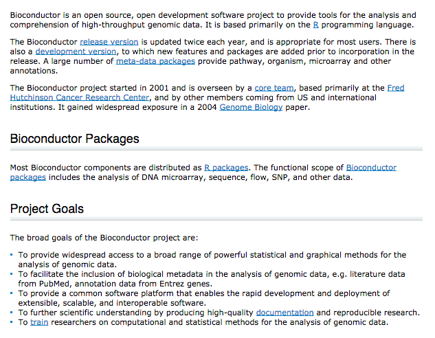

[Link to BioC packages](http://www.bioconductor.org/packages/release/BiocViews.html#___Software)

# Bioconductor

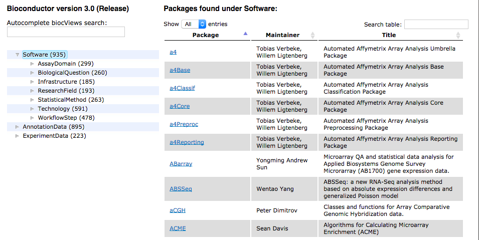

# Bioconductor

- The `biocLite` function makes added and updated BioC packages easy:

```r
biocLite(c("GenomicFeatures", "AnnotationDbi"))
```

# COMP-364 (c) M Hallett, BCI-McGill

[figure not shown]